# Image Processing Project Report

### Part 6

**Note:** The Euclidean distance between two points in $n$ dimensions is $d(p,c) = \sqrt{\sum (p_i - c_i)^2}$.

```python
%%bash --login
make superpixel-test
```

```
make: 'superpixel-test' is up to date.
```

```python
! ./superpixel-test
```

```
Tests de la fonction distancePoints
Tests de la fonction plusProcheVoisin
Tests de la fonction KMoyenne
Tests de la fonction superPixel
Vérifier que les images obtenues dans 'superpixel/' sont semblables à celles fournies dans 'superpixel/correction/'
```

```
Proposer des paramètres pour Embryos.512.ppm et House.256.ppm et ajouter des tests ci-dessous
```

- We represent each point by a five-dimensional vector (including its x,y position and RGB color), and apply K-means to cluster points that are similar in both position and color.
- The parameter $\lambda$ is used to balance the influence of spatial versus color components while keeping them in the same feature vector.

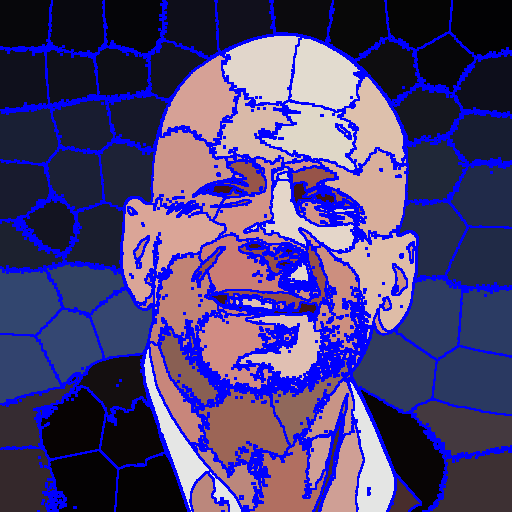

```python
from open_ppm import open_ppm
im = open_ppm("superpixel/Willis.512.ppm")
im.resize((512*im.width // im.height, 512))
```

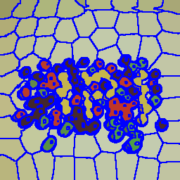

```python
from open_ppm import open_ppm
im = open_ppm("superpixel/Billes.256.ppm")
im.resize((256*im.width // im.height, 256))
```

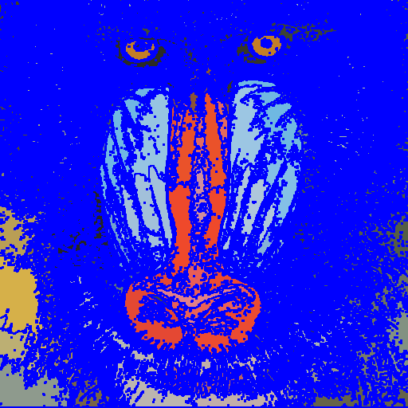

```python
from open_ppm import open_ppm
im = open_ppm("superpixel/Baboon.512.ppm")
im.resize((512*im.width // im.height, 512))
```

**Note:** The Baboon image naturally has significant color differences between adjacent regions, resembling the texture of animal fur.

## Retrospective

We spent over 30 hours (including lab sessions and independent work) on this project; it was both challenging and rewarding. Sichao took the lead on implementing the more complex parts of the code, while I (Nguyen) focused on the report/documentation and on the simpler tasks. Once the first part was completed — which was the most time-consuming — the later steps proceeded quite naturally. We of course made some minor errors that cost us time (such as missing commas or redeclaring variables), and we also worked out simple examples on paper to understand how the functions should behave. At times we tried to optimize the code by making it more concise or by adding early `break` statements so that loops would stop once conditions were met. We found working in a pair with Jupyter very effective, especially when collaborating from two different computers with instant saving. The built-in Markdown support in Jupyter was also very helpful, providing a clearer and more pleasant presentation of our code and documentation. Overall, this project was an excellent preparation for our exams, pushing us to think critically and sometimes to search for solutions on the Internet; we finished it with a great sense of satisfaction.